# Consonant durations in onset

# 1 Data preprocessing

## 1.1 Load required packages

```r
library(tidyr)
library(dplyr)
library(stringr)
library(car)
library(visreg)
library(lmerTest)
```

```r
library(ggplot2)
library(mgcv)
library(itsadug)
```

## 1.2 Read data

```r
df <- readRDS("C:/Users/Jidde/Desktop/analysis/data/modelling_data.rds")
df <- rename(df, onset_type = condition)
```

### 1.2.1 Tweak data

```r
# Change order of levels in cluster
df$cluster <- relevel(df$cluster, ref = "sp")
df$subj <- as.factor(df$subj)
df$dur <- as.numeric(df$dur)
df <- drop_na(df, dur)
df$onset_type <- relevel(df$onset_type, ref = "C")



df.onset.sp <- df[df$seg == "p" & df$cluster == "sp",]
df.onset.sm <- df[df$seg == "m",]
df.onset.sx <- df[df$seg == "X",]

df.onset <- rbind(df.onset.sp, df.onset.sm, df.onset.sx) # drop spr cluster
rm(df.onset.sp, df.onset.sm, df.onset.sx)

table(df.onset$subj, df.onset$trial)
```

[output not shown]

[output cut: 484 more lines]

[output not shown]

```r
df.onset.s <- df[df$seg == "s" & df$onset_type == "CC",]

df.onset$onset_type <- recode_factor(df.onset$onset_type, C = "singleton",
                                CC = "cluster")

df.onset$group <- recode_factor(df.onset$group, CTRL = "typical")
df.onset$group<- relevel(df.onset$group, ref = "PD")
```

Create ordered factor:

```r
df.onset$group.ord <- as.ordered(df.onset$group)
contrasts(df.onset$group.ord) <- "contr.treatment"

df.onset$gender.ord <- as.ordered(df.onset$gender)
contrasts(df.onset$gender.ord) <- "contr.treatment"
```

Create binary dummy variables:

```r
df.onset$IsTP <- (df.onset$group == "typical")*1
```

Visualize:

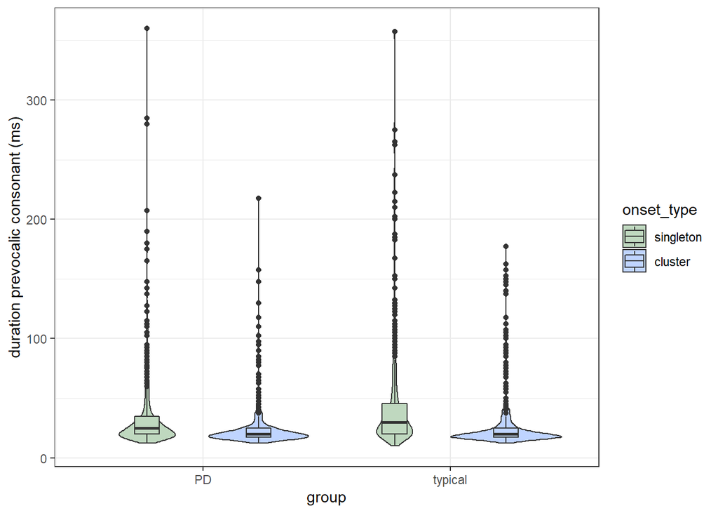

```r
dodge = .5
dodge <- position_dodge(width = 0.9)

ggplot(df.onset, aes(x=group, y=dur, fill=onset_type)) + geom_violin() + geom_boxplot(width=.2, position = dodge) + labs(y = "duration prevocalic consonant (ms)") + scale_fill_manual(values=c("#bfd8bf", "#bfd4ff")) + theme_bw()
```

```r
dodge <- position_dodge(width = 0.9)
```

# 2 Duration of prevocalic consonant

Fitting first model:

```r
summary(m <- bam(dur ~ s(subj, bs='re'), data=df.onset, method = "ML"))
```

```
##
## Family: gaussian
## Link function: identity
##
## Formula:
## dur ~ s(subj, bs = "re")
##
## Parametric coefficients:
##             Estimate Std. Error t value Pr(>|t|)
## (Intercept)   32.790      1.551   21.14   <2e-16 ***
## ---
## Signif. codes:  0 '***' 0.001 '**' 0.01 '*' 0.05 '.' 0.1 ' ' 1
##
## Approximate significance of smooth terms:
##           edf Ref.df     F p-value
## s(subj) 38.76     46 5.891  <2e-16 ***
## ---
## Signif. codes:  0 '***' 0.001 '**' 0.01 '*' 0.05 '.' 0.1 ' ' 1
##
## R-sq.(adj) =  0.101   Deviance explained = 11.5%
## -ML =  11671  Scale est. = 851.83    n = 2426
```

Adding onset_type as fixed effect:

```r
summary(m1 <- bam(dur ~  onset_type + s(subj, bs='re'), data=df.onset, method = "ML"))
```

```
##
## Family: gaussian
## Link function: identity
##
## Formula:
## dur ~ onset_type + s(subj, bs = "re")
##
## Parametric coefficients:
##                   Estimate Std. Error t value Pr(>|t|)
## (Intercept)         39.208      1.662   23.59   <2e-16 ***
## onset_typecluster  -12.904      1.158  -11.15   <2e-16 ***
## ---
## Signif. codes:  0 '***' 0.001 '**' 0.01 '*' 0.05 '.' 0.1 ' ' 1
##
## Approximate significance of smooth terms:
##           edf Ref.df     F p-value
## s(subj) 39.17     46 6.316  <2e-16 ***
## ---
## Signif. codes:  0 '***' 0.001 '**' 0.01 '*' 0.05 '.' 0.1 ' ' 1
##
## R-sq.(adj) =  0.145   Deviance explained = 15.9%
## -ML =  11611  Scale est. = 809.72    n = 2426
```

```r
compareML(m, m1)
```

```
## m: dur ~ s(subj, bs = "re")
##
## m1: dur ~ onset_type + s(subj, bs = "re")
```

```
##
## Chi-square test of ML scores
## -----
##   Model    Score Edf Difference    Df  p.value Sig.
## 1     m 11671.28   2
## 2    m1 11610.70   3     60.580 1.000  < 2e-16  ***
##
## AIC difference: 121.64, model m1 has lower AIC.
```

Sign. improvement.

Add random slopes over onset_type:

```r
summary(m2REML <- bam(dur ~ onset_type + s(onset_type, bs = "fs", m = 1), data=df.onset , method = "REML"))
```

```
##
## Family: gaussian
## Link function: identity
##
## Formula:
## dur ~ onset_type + s(onset_type, bs = "fs", m = 1)
##
## Parametric coefficients:
##                   Estimate Std. Error t value Pr(>|t|)
## (Intercept)         39.396      1.222  32.241  < 2e-16 ***
## onset_typecluster  -12.749      1.729  -7.371  2.3e-13 ***
## ---
## Signif. codes:  0 '***' 0.001 '**' 0.01 '*' 0.05 '.' 0.1 ' ' 1
##
## Approximate significance of smooth terms:
##                     edf Ref.df F p-value
## s(onset_type) 5.847e-17      2 0   0.166
##
## R-sq.(adj) =  0.0425   Deviance explained = 4.29%
## -REML =  11701  Scale est. = 907.05    n = 2426
```

Adding random slopes for onset_type:

```r
summary(m2REML <- bam(dur ~ onset_type + s(subj, bs='re') +  s(subj, onset_type, bs = "re"), data=df.onset , method = "REML"))
```

```
##
## Family: gaussian
## Link function: identity
##
## Formula:
## dur ~ onset_type + s(subj, bs = "re") + s(subj, onset_type, bs = "re")
##
## Parametric coefficients:
##                   Estimate Std. Error t value Pr(>|t|)
## (Intercept)         39.165      2.045   19.15  < 2e-16 ***
## onset_typecluster  -12.442      2.571   -4.84 1.38e-06 ***
## ---
## Signif. codes:  0 '***' 0.001 '**' 0.01 '*' 0.05 '.' 0.1 ' ' 1
##
## Approximate significance of smooth terms:
##                      edf Ref.df     F p-value
## s(subj)            15.88     46 5.720  0.0171 *
## s(subj,onset_type) 60.82     92 6.768  <2e-16 ***
## ---
## Signif. codes:  0 '***' 0.001 '**' 0.01 '*' 0.05 '.' 0.1 ' ' 1
##
## R-sq.(adj) =  0.212   Deviance explained = 23.8%
## -REML =  11549  Scale est. = 746.22    n = 2426
```

Sign. improvement.

Adding group as fixed effect:

```r
summary(m2ML <- bam(dur ~ onset_type + s(subj, bs='re') + s(subj, onset_type, bs = "re"), data=df.onset , method = "ML"))
```

```
##
## Family: gaussian
## Link function: identity
##
## Formula:
## dur ~ onset_type + s(subj, bs = "re") + s(subj, onset_type, bs = "re")
##
## Parametric coefficients:
##                   Estimate Std. Error t value Pr(>|t|)
## (Intercept)         39.168      2.023  19.361  < 2e-16 ***
## onset_typecluster  -12.446      2.543  -4.894 1.06e-06 ***
## ---
## Signif. codes:  0 '***' 0.001 '**' 0.01 '*' 0.05 '.' 0.1 ' ' 1
##
## Approximate significance of smooth terms:
##                      edf Ref.df     F p-value
## s(subj)            15.88     46 5.609  0.0128 *
## s(subj,onset_type) 60.51     92 6.649  <2e-16 ***
## ---
## Signif. codes:  0 '***' 0.001 '**' 0.01 '*' 0.05 '.' 0.1 ' ' 1
##
## R-sq.(adj) =  0.212   Deviance explained = 23.7%
## -ML =  11553  Scale est. = 746.32    n = 2426
```

```r
summary(m3ML <- bam(dur ~ group  + onset_type + s(subj, bs='re') + s(subj, onset_type, bs = "re"), data=df.onset , method = "ML"))
```

```
##
## Family: gaussian
## Link function: identity
##
## Formula:
## dur ~ group + onset_type + s(subj, bs = "re") + s(subj, onset_type,
##     bs = "re")
##
## Parametric coefficients:
##                   Estimate Std. Error t value Pr(>|t|)
## (Intercept)         36.583      2.542  14.392  < 2e-16 ***
## grouptypical         5.014      3.064   1.636    0.102
## onset_typecluster  -12.440      2.543  -4.891 1.07e-06 ***
## ---
## Signif. codes:  0 '***' 0.001 '**' 0.01 '*' 0.05 '.' 0.1 ' ' 1
##
## Approximate significance of smooth terms:
##                      edf Ref.df     F p-value
## s(subj)            13.87     45 4.374  0.0209 *
## s(subj,onset_type) 61.31     91 6.451  <2e-16 ***
## ---
## Signif. codes:  0 '***' 0.001 '**' 0.01 '*' 0.05 '.' 0.1 ' ' 1
##
## R-sq.(adj) =  0.212   Deviance explained = 23.7%
## -ML =  11551  Scale est. = 746.35    n = 2426
```

```r
compareML(m2ML, m3ML)
```

```
## m2ML: dur ~ onset_type + s(subj, bs = "re") + s(subj, onset_type, bs = "re")
##
## m3ML: dur ~ group + onset_type + s(subj, bs = "re") + s(subj, onset_type,
##     bs = "re")
```

```
##
## Chi-square test of ML scores
## -----
##   Model    Score Edf Difference    Df p.value Sig.
## 1  m2ML 11552.69   4
## 2  m3ML 11551.39   5      1.303 1.000   0.106
##
## AIC difference: -1.00, model m2ML has lower AIC.
```

No improv.

Adding interaction as fixed effect:

```r
summary(m4ML <- bam(dur ~ group*onset_type + s(subj, bs='re') + s(subj, onset_type, bs = "re"), data=df.onset , method = "ML"))
```

```
##
## Family: gaussian
## Link function: identity
##
## Formula:
## dur ~ group * onset_type + s(subj, bs = "re") + s(subj, onset_type,
##     bs = "re")
##
## Parametric coefficients:
##                                Estimate Std. Error t value Pr(>|t|)
## (Intercept)                      34.956      2.846  12.284   <2e-16 ***
## grouptypical                      8.161      3.959   2.061   0.0394 *
## onset_typecluster                -9.190      3.606  -2.548   0.0109 *
## grouptypical:onset_typecluster   -6.299      5.015  -1.256   0.2093
## ---
## Signif. codes:  0 '***' 0.001 '**' 0.01 '*' 0.05 '.' 0.1 ' ' 1
##
## Approximate significance of smooth terms:
##                      edf Ref.df     F p-value
## s(subj)            14.78     45 4.809  0.0142 *
## s(subj,onset_type) 59.34     90 6.334  <2e-16 ***
## ---
## Signif. codes:  0 '***' 0.001 '**' 0.01 '*' 0.05 '.' 0.1 ' ' 1
##
## R-sq.(adj) =  0.212   Deviance explained = 23.7%
## -ML =  11551  Scale est. = 746.36    n = 2426
```

```r
compareML(m2ML, m4ML)
```

```
## m2ML: dur ~ onset_type + s(subj, bs = "re") + s(subj, onset_type, bs = "re")
##
## m4ML: dur ~ group * onset_type + s(subj, bs = "re") + s(subj, onset_type,
##     bs = "re")
```

```
##
## Chi-square test of ML scores
## -----
##   Model    Score Edf Difference    Df p.value Sig.
## 1  m2ML 11552.69   4
## 2  m4ML 11550.61   6      2.081 2.000   0.125
##
## AIC difference: -0.38, model m2ML has lower AIC.
```

No improvement.

Add cluster

```r
summary(m5ML <- bam(dur ~ onset_type + cluster + s(subj, bs='re') + s(subj, onset_type, bs = "re"), data=df.onset , method = "ML"))
```

```
##
## Family: gaussian
## Link function: identity
##
## Formula:
## dur ~ onset_type + cluster + s(subj, bs = "re") + s(subj, onset_type,
##     bs = "re")
##
## Parametric coefficients:
##                   Estimate Std. Error t value Pr(>|t|)
## (Intercept)         37.931      2.136  17.759  < 2e-16 ***
## onset_typecluster  -12.394      2.541  -4.877 1.15e-06 ***
## clustersm           -2.817      1.306  -2.157   0.0311 *
## clustersx            7.743      1.377   5.625 2.08e-08 ***
## ---
## Signif. codes:  0 '***' 0.001 '**' 0.01 '*' 0.05 '.' 0.1 ' ' 1
##
## Approximate significance of smooth terms:
##                      edf Ref.df     F p-value
## s(subj)            15.19     46 5.307  0.0151 *
## s(subj,onset_type) 61.39     92 6.868  <2e-16 ***
## ---
## Signif. codes:  0 '***' 0.001 '**' 0.01 '*' 0.05 '.' 0.1 ' ' 1
##
## R-sq.(adj) =  0.231   Deviance explained = 25.6%
## -ML =  11523  Scale est. = 728.49    n = 2426
```

```r
compareML(m2ML, m5ML)
```

```
## m2ML: dur ~ onset_type + s(subj, bs = "re") + s(subj, onset_type, bs = "re")
##
## m5ML: dur ~ onset_type + cluster + s(subj, bs = "re") + s(subj, onset_type,
##     bs = "re")
```

```
##
## Chi-square test of ML scores
## -----
##   Model    Score Edf Difference    Df   p.value Sig.
## 1  m2ML 11552.69   4
## 2  m5ML 11522.86   6     29.830 2.000 1.109e-13  ***
##
## AIC difference: 56.18, model m5ML has lower AIC.
```

Sign. improvement.

Add random slopes for cluster:

```r
summary(m6 <- bam(dur ~ onset_type + cluster + s(subj, bs='re') + s(subj, onset_type, bs = "re") + s(subj, cluster, bs = "re"), data=df.onset))
```

```
##
## Family: gaussian
## Link function: identity
##
## Formula:
## dur ~ onset_type + cluster + s(subj, bs = "re") + s(subj, onset_type,
##     bs = "re") + s(subj, cluster, bs = "re")
##
## Parametric coefficients:
##                   Estimate Std. Error t value Pr(>|t|)
## (Intercept)         38.259      2.789  13.719  < 2e-16 ***
## onset_typecluster  -12.652      2.475  -5.113 3.44e-07 ***
## clustersm           -3.164      3.159  -1.002   0.3166
## clustersx            7.649      3.227   2.370   0.0179 *
## ---
## Signif. codes:  0 '***' 0.001 '**' 0.01 '*' 0.05 '.' 0.1 ' ' 1
##
## Approximate significance of smooth terms:
##                          edf Ref.df     F p-value
## s(subj)            1.711e-04     46 0.000  0.7967
## s(subj,onset_type) 5.755e+01     92 9.796  0.0002 ***
## s(subj,cluster)    9.801e+01    136 9.546  <2e-16 ***
## ---
## Signif. codes:  0 '***' 0.001 '**' 0.01 '*' 0.05 '.' 0.1 ' ' 1
##
## R-sq.(adj) =  0.379   Deviance explained =   42%
## fREML =  11356  Scale est. = 588.24    n = 2426
```

Imrpov.

Adding onset_type*cluster as fixed effect:

```r
summary(m6ML <- bam(dur ~ onset_type + cluster + s(subj, bs='re') + s(subj, onset_type, bs = "re") + s(subj, cluster, bs = "re"), data=df.onset , method = "ML"))
```

```
##
## Family: gaussian
## Link function: identity
##
## Formula:
## dur ~ onset_type + cluster + s(subj, bs = "re") + s(subj, onset_type,
##     bs = "re") + s(subj, cluster, bs = "re")
##
## Parametric coefficients:
##                   Estimate Std. Error t value Pr(>|t|)
## (Intercept)         38.258      2.758  13.871  < 2e-16 ***
## onset_typecluster  -12.654      2.449  -5.167 2.58e-07 ***
## clustersm           -3.164      3.125  -1.013   0.3114
## clustersx            7.652      3.193   2.396   0.0166 *
## ---
## Signif. codes:  0 '***' 0.001 '**' 0.01 '*' 0.05 '.' 0.1 ' ' 1
##
## Approximate significance of smooth terms:
##                          edf Ref.df     F  p-value
## s(subj)             0.004429     46 0.000 0.766151
## s(subj,onset_type) 57.345910     92 9.610 0.000111 ***
## s(subj,cluster)    97.661483    136 9.395  < 2e-16 ***
## ---
## Signif. codes:  0 '***' 0.001 '**' 0.01 '*' 0.05 '.' 0.1 ' ' 1
##
## R-sq.(adj) =  0.379   Deviance explained = 41.9%
## -ML =  11363  Scale est. = 588.39    n = 2426
```

```r
summary(m7 <- bam(dur ~ onset_type*cluster + s(subj, bs='re') + s(subj, onset_type, bs = "re") + s(subj, cluster, bs = "re"), data=df.onset , method = "ML"))
```

```
##
## Family: gaussian
## Link function: identity
##
## Formula:
## dur ~ onset_type * cluster + s(subj, bs = "re") + s(subj, onset_type,
##     bs = "re") + s(subj, cluster, bs = "re")
##
## Parametric coefficients:
##                             Estimate Std. Error t value Pr(>|t|)
## (Intercept)                   39.279      2.840  13.829  < 2e-16 ***
## onset_typecluster            -14.674      2.789  -5.262 1.56e-07 ***
## clustersm                     -2.360      3.332  -0.708 0.478863
## clustersx                      3.184      3.409   0.934 0.350350
## onset_typecluster:clustersm   -1.637      2.349  -0.697 0.485981
## onset_typecluster:clustersx    9.186      2.475   3.711 0.000211 ***
## ---
## Signif. codes:  0 '***' 0.001 '**' 0.01 '*' 0.05 '.' 0.1 ' ' 1
##
## Approximate significance of smooth terms:
##                          edf Ref.df      F  p-value
## s(subj)            3.124e-04     46  0.000    0.772
## s(subj,onset_type) 5.789e+01     92 10.020 9.99e-05 ***
## s(subj,cluster)    9.743e+01    136  9.498  < 2e-16 ***
## ---
## Signif. codes:  0 '***' 0.001 '**' 0.01 '*' 0.05 '.' 0.1 ' ' 1
##
## R-sq.(adj) =  0.384   Deviance explained = 42.5%
## -ML =  11353  Scale est. = 583.28    n = 2426
```

```r
compareML(m6ML, m7)
```

```
## m6ML: dur ~ onset_type + cluster + s(subj, bs = "re") + s(subj, onset_type,
##     bs = "re") + s(subj, cluster, bs = "re")
##
## m7: dur ~ onset_type * cluster + s(subj, bs = "re") + s(subj, onset_type,
##     bs = "re") + s(subj, cluster, bs = "re")
```

```
##
## Chi-square test of ML scores
## -----
##   Model    Score Edf Difference    Df   p.value Sig.
## 1  m6ML 11363.46   7
## 2    m7 11353.00   9     10.467 2.000 2.845e-05  ***
##
## AIC difference: 19.28, model m7 has lower AIC.
```

Sign. improv.

Adding duration.tt fixed effect:

```r
df.onset$duration.tt <- df.onset$duration.tt - mean(df.onset$duration.tt) # center continues variable
summary(m8 <- bam(dur ~ onset_type*cluster + s(duration.tt) + s(subj, bs='re') + s(subj, onset_type, bs = "re") + s(subj, cluster, bs = "re"), method = "ML", data=df.onset))
```

```
##
## Family: gaussian
## Link function: identity
##
## Formula:
## dur ~ onset_type * cluster + s(duration.tt) + s(subj, bs = "re") +
##     s(subj, onset_type, bs = "re") + s(subj, cluster, bs = "re")
##
## Parametric coefficients:
##                             Estimate Std. Error t value Pr(>|t|)
## (Intercept)                   39.087      2.685  14.557  < 2e-16 ***
## onset_typecluster            -14.375      2.636  -5.453 5.49e-08 ***
## clustersm                     -2.846      3.172  -0.897    0.370
## clustersx                      2.989      3.246   0.921    0.357
## onset_typecluster:clustersm   -1.996      2.283  -0.874    0.382
## onset_typecluster:clustersx   10.196      2.406   4.237 2.36e-05 ***
## ---
## Signif. codes:  0 '***' 0.001 '**' 0.01 '*' 0.05 '.' 0.1 ' ' 1
##
## Approximate significance of smooth terms:
##                         edf Ref.df       F  p-value
## s(duration.tt)      1.00016      1 154.734  < 2e-16 ***
## s(subj)             0.01799     46   0.000  0.99068
## s(subj,onset_type) 56.80249     92   7.288  0.00354 **
## s(subj,cluster)    96.83469    136   6.925 1.05e-05 ***
## ---
## Signif. codes:  0 '***' 0.001 '**' 0.01 '*' 0.05 '.' 0.1 ' ' 1
##
## R-sq.(adj) =  0.418   Deviance explained = 45.7%
## -ML =  11278  Scale est. = 550.91    n = 2426
```

```r
compareML(m7, m8)
```

```
## m7: dur ~ onset_type * cluster + s(subj, bs = "re") + s(subj, onset_type,
##     bs = "re") + s(subj, cluster, bs = "re")
##
## m8: dur ~ onset_type * cluster + s(duration.tt) + s(subj, bs = "re") +
##     s(subj, onset_type, bs = "re") + s(subj, cluster, bs = "re")
```

```
##
## Chi-square test of ML scores
## -----
##   Model    Score Edf Difference    Df  p.value Sig.
## 1    m7 11353.00   9
## 2    m8 11278.01  11     74.987 2.000  < 2e-16  ***
##
## AIC difference: 138.09, model m8 has lower AIC.
```

Sign. improvement.

Add slopes:

```r
summary(m9 <- bam(dur ~ onset_type*cluster + s(duration.tt) + s(subj, onset_type, bs = "re") + s(subj, cluster, bs = "re")  + s(duration.tt, subj, bs = "fs", m =1), data=df.onset))
```

```
##
## Family: gaussian
## Link function: identity
##
## Formula:
## dur ~ onset_type * cluster + s(duration.tt) + s(subj, onset_type,
##     bs = "re") + s(subj, cluster, bs = "re") + s(duration.tt,
##     subj, bs = "fs", m = 1)
##
## Parametric coefficients:
##                             Estimate Std. Error t value Pr(>|t|)
## (Intercept)                   39.428      2.824  13.964  < 2e-16 ***
## onset_typecluster            -14.079      2.591  -5.434 6.12e-08 ***
## clustersm                     -3.029      3.230  -0.938    0.348
## clustersx                      3.277      3.310   0.990    0.322
## onset_typecluster:clustersm   -2.495      2.226  -1.121    0.262
## onset_typecluster:clustersx    9.392      2.354   3.989 6.85e-05 ***
## ---
## Signif. codes:  0 '***' 0.001 '**' 0.01 '*' 0.05 '.' 0.1 ' ' 1
##
## Approximate significance of smooth terms:
##                        edf  Ref.df      F p-value
## s(duration.tt)       1.356   1.477 22.938  <2e-16 ***
## s(subj,onset_type)  52.503  92.000  3.446  <2e-16 ***
## s(subj,cluster)     94.564 136.000  4.861  <2e-16 ***
## s(duration.tt,subj) 73.179 378.000  2.457  0.0897 .
## ---
## Signif. codes:  0 '***' 0.001 '**' 0.01 '*' 0.05 '.' 0.1 ' ' 1
##
## R-sq.(adj) =  0.464   Deviance explained = 51.4%
## fREML =  11232  Scale est. = 508.07    n = 2426
```

Not required.

Check if there’s a group difference:

```r
summary(m9group <- bam(dur ~ onset_type*cluster + s(duration.tt) + s(duration.tt, by = IsTP) + s(subj, bs = "re") + s(subj, onset_type, bs = "re") + s(subj, cluster, bs = "re"), data=df.onset))
```

```
##
## Family: gaussian
## Link function: identity
##
## Formula:
## dur ~ onset_type * cluster + s(duration.tt) + s(duration.tt,
##     by = IsTP) + s(subj, bs = "re") + s(subj, onset_type, bs = "re") +
##     s(subj, cluster, bs = "re")
##
## Parametric coefficients:
##                             Estimate Std. Error t value Pr(>|t|)
## (Intercept)                   38.498      3.202  12.023  < 2e-16 ***
## onset_typecluster            -14.233      2.661  -5.349 9.73e-08 ***
## clustersm                     -2.799      3.194  -0.876    0.381
## clustersx                      3.197      3.269   0.978    0.328
## onset_typecluster:clustersm   -2.245      2.271  -0.989    0.323
## onset_typecluster:clustersx    9.816      2.395   4.099 4.30e-05 ***
## ---
## Signif. codes:  0 '***' 0.001 '**' 0.01 '*' 0.05 '.' 0.1 ' ' 1
##
## Approximate significance of smooth terms:
##                           edf  Ref.df      F  p-value
## s(duration.tt)      4.445e+00   5.444 13.352  < 2e-16 ***
## s(duration.tt):IsTP 7.040e+00   8.100  2.928  0.00275 **
## s(subj)             3.379e-04  45.000  0.000  0.98150
## s(subj,onset_type)  5.669e+01  91.000  7.138  0.00270 **
## s(subj,cluster)     9.643e+01 135.000  6.814 6.98e-06 ***
## ---
## Signif. codes:  0 '***' 0.001 '**' 0.01 '*' 0.05 '.' 0.1 ' ' 1
##
## R-sq.(adj) =  0.426   Deviance explained = 46.7%
## fREML =  11258  Scale est. = 543.31    n = 2426
```

Yes.

Add appropriate random smooths:

```r
summary(m9group_slope <- bam(dur ~ onset_type*cluster + s(duration.tt) + s(duration.tt, by = IsTP) + s(subj, bs = "re") + s(subj, onset_type, bs = "re") + s(subj, cluster, bs = "re") + s(duration.tt, subj, bs = "fs", m =1) + s(duration.tt, subj, by = IsTP, bs = "fs", m =1), data=df.onset))
```

```
##
## Family: gaussian
## Link function: identity
##
## Formula:
## dur ~ onset_type * cluster + s(duration.tt) + s(duration.tt,
##     by = IsTP) + s(subj, bs = "re") + s(subj, onset_type, bs = "re") +
##     s(subj, cluster, bs = "re") + s(duration.tt, subj, bs = "fs",
##     m = 1) + s(duration.tt, subj, by = IsTP, bs = "fs", m = 1)
##
## Parametric coefficients:
##                             Estimate Std. Error t value Pr(>|t|)
## (Intercept)                   38.343      3.286  11.668  < 2e-16 ***
## onset_typecluster            -14.031      2.564  -5.472 4.96e-08 ***
## clustersm                     -3.017      3.224  -0.936    0.349
## clustersx                      3.436      3.304   1.040    0.298
## onset_typecluster:clustersm   -2.468      2.218  -1.113    0.266
## onset_typecluster:clustersx    9.206      2.347   3.922 9.04e-05 ***
## ---
## Signif. codes:  0 '***' 0.001 '**' 0.01 '*' 0.05 '.' 0.1 ' ' 1
##
## Approximate significance of smooth terms:
##                                edf  Ref.df     F  p-value
## s(duration.tt)           2.713e+00   3.179 7.750 4.07e-05 ***
## s(duration.tt):IsTP      2.000e+00   2.000 0.236   0.7900
## s(subj)                  7.108e-05  45.000 0.000   0.9617
## s(subj,onset_type)       5.137e+01  91.000 3.308  < 2e-16 ***
## s(subj,cluster)          9.393e+01 135.000 4.873  < 2e-16 ***
## s(duration.tt,subj)      3.699e+01 382.000 0.609   0.0587 .
## s(duration.tt,subj):IsTP 3.875e+01 204.000 0.419  < 2e-16 ***
## ---
## Signif. codes:  0 '***' 0.001 '**' 0.01 '*' 0.05 '.' 0.1 ' ' 1
##
## R-sq.(adj) =  0.469   Deviance explained = 51.9%
## fREML =  11224  Scale est. = 503.45    n = 2426
```

Not sign. anymore.

Adding recording.no as fixed effect:

```r
summary(m9groupML <- bam(dur ~ group.ord + onset_type*cluster + s(duration.tt) + s(subj, bs = "re") + s(subj, onset_type, bs = "re") + s(subj, cluster, bs = "re"), data=df.onset, method = "ML"))
```

```
##
## Family: gaussian
## Link function: identity
##
## Formula:
## dur ~ group.ord + onset_type * cluster + s(duration.tt) + s(subj,
##     bs = "re") + s(subj, onset_type, bs = "re") + s(subj, cluster,
##     bs = "re")
##
## Parametric coefficients:
##                             Estimate Std. Error t value Pr(>|t|)
## (Intercept)                  38.8568     3.1615  12.290  < 2e-16 ***
## group.ordtypical              0.4478     3.2525   0.138    0.891
## onset_typecluster           -14.3751     2.6362  -5.453 5.49e-08 ***
## clustersm                    -2.8448     3.1716  -0.897    0.370
## clustersx                     2.9803     3.2465   0.918    0.359
## onset_typecluster:clustersm  -1.9969     2.2832  -0.875    0.382
## onset_typecluster:clustersx  10.1942     2.4064   4.236 2.36e-05 ***
## ---
## Signif. codes:  0 '***' 0.001 '**' 0.01 '*' 0.05 '.' 0.1 ' ' 1
##
## Approximate significance of smooth terms:
##                         edf Ref.df       F  p-value
## s(duration.tt)      1.00017      1 152.305  < 2e-16 ***
## s(subj)             0.01627     45   0.000  0.98759
## s(subj,onset_type) 56.38290     91   7.308  0.00299 **
## s(subj,cluster)    96.35598    135   6.968 7.18e-06 ***
## ---
## Signif. codes:  0 '***' 0.001 '**' 0.01 '*' 0.05 '.' 0.1 ' ' 1
##
## R-sq.(adj) =  0.418   Deviance explained = 45.7%
## -ML =  11278  Scale est. = 550.94    n = 2426
```

```r
summary(m10 <- bam(dur ~ group.ord + onset_type*cluster + s(duration.tt)  + s(recording.no) + s(subj, bs = "re") + s(subj, onset_type, bs = "re") + s(subj, cluster, bs = "re"), data=df.onset, method = "ML"))
```

```
##
## Family: gaussian
## Link function: identity
##
## Formula:
## dur ~ group.ord + onset_type * cluster + s(duration.tt) + s(recording.no) +
##     s(subj, bs = "re") + s(subj, onset_type, bs = "re") + s(subj,
##     cluster, bs = "re")
##
## Parametric coefficients:
##                             Estimate Std. Error t value Pr(>|t|)
## (Intercept)                  38.8074     3.1614  12.275  < 2e-16 ***
## group.ordtypical              0.5252     3.2531   0.161    0.872
## onset_typecluster           -14.3798     2.6355  -5.456 5.40e-08 ***
## clustersm                    -2.8366     3.1713  -0.894    0.371
## clustersx                     2.9704     3.2462   0.915    0.360
## onset_typecluster:clustersm  -1.9982     2.2835  -0.875    0.382
## onset_typecluster:clustersx  10.2025     2.4068   4.239 2.33e-05 ***
## ---
## Signif. codes:  0 '***' 0.001 '**' 0.01 '*' 0.05 '.' 0.1 ' ' 1
##
## Approximate significance of smooth terms:
##                         edf  Ref.df       F  p-value
## s(duration.tt)      1.00054   1.001 136.549  < 2e-16 ***
## s(recording.no)     1.00072   1.001   0.578   0.4478
## s(subj)             0.01411  45.000   0.000   0.9879
## s(subj,onset_type) 56.36079  91.000   7.299   0.0029 **
## s(subj,cluster)    96.34431 135.000   6.962 6.86e-06 ***
## ---
## Signif. codes:  0 '***' 0.001 '**' 0.01 '*' 0.05 '.' 0.1 ' ' 1
##
## R-sq.(adj) =  0.418   Deviance explained = 45.7%
## -ML =  11278  Scale est. = 551.08    n = 2426
```

```r
compareML(m9groupML, m10)
```

```
## m9groupML: dur ~ group.ord + onset_type * cluster + s(duration.tt) + s(subj,
##     bs = "re") + s(subj, onset_type, bs = "re") + s(subj, cluster,
##     bs = "re")
##
## m10: dur ~ group.ord + onset_type * cluster + s(duration.tt) + s(recording.no) +
##     s(subj, bs = "re") + s(subj, onset_type, bs = "re") + s(subj,
##     cluster, bs = "re")
```

```
##
## Chi-square test of ML scores
## -----
##       Model    Score Edf Difference    Df p.value Sig.
## 1 m9groupML 11278.00  12
## 2       m10 11277.71  14      0.288 2.000   0.750
##
## AIC difference: -1.42, model m9groupML has lower AIC.
```

No improvement.

Recording.no separate for group?

```r
summary(m11 <- bam(dur ~ group.ord + onset_type*cluster + s(duration.tt) + s(recording.no) + s(recording.no, by = IsTP) + s(subj, bs = "re") + s(subj, onset_type, bs = "re") + s(subj, cluster, bs = "re"), data=df.onset))
```

```
##
## Family: gaussian
## Link function: identity
##
## Formula:
## dur ~ group.ord + onset_type * cluster + s(duration.tt) + s(recording.no) +
##     s(recording.no, by = IsTP) + s(subj, bs = "re") + s(subj,
##     onset_type, bs = "re") + s(subj, cluster, bs = "re")
##
## Parametric coefficients:
##                             Estimate Std. Error t value Pr(>|t|)
## (Intercept)                  38.7500     3.1982  12.116  < 2e-16 ***
## group.ordtypical              0.6137     3.2954   0.186    0.852
## onset_typecluster           -14.3762     2.6579  -5.409 7.01e-08 ***
## clustersm                    -2.8516     3.2012  -0.891    0.373
## clustersx                     3.0662     3.2765   0.936    0.349
## onset_typecluster:clustersm  -1.9996     2.2819  -0.876    0.381
## onset_typecluster:clustersx  10.1035     2.4060   4.199 2.78e-05 ***
## ---
## Signif. codes:  0 '***' 0.001 '**' 0.01 '*' 0.05 '.' 0.1 ' ' 1
##
## Approximate significance of smooth terms:
##                            edf  Ref.df      F  p-value
## s(duration.tt)       3.205e+00   4.082 34.677  < 2e-16 ***
## s(recording.no)      1.000e+00   1.000  1.310  0.25252
## s(recording.no):IsTP 1.000e+00   1.000  0.422  0.51595
## s(subj)              1.123e-04  45.000  0.000  0.99139
## s(subj,onset_type)   5.656e+01  91.000  7.313  0.00329 **
## s(subj,cluster)      9.665e+01 135.000  6.986 8.58e-06 ***
## ---
## Signif. codes:  0 '***' 0.001 '**' 0.01 '*' 0.05 '.' 0.1 ' ' 1
##
## Rank: 316/317
## R-sq.(adj) =  0.419   Deviance explained = 45.9%
## fREML =  11262  Scale est. = 549.97    n = 2426
```

No.

Adding gender as fixed effect:

```r
summary(m11ML <- bam(dur ~ group.ord + onset_type*cluster + s(duration.tt) + s(subj, bs = "re") + s(subj, onset_type, bs = "re") + s(subj, cluster, bs = "re"), data=df.onset, method = "ML"))
```

```
##
## Family: gaussian
## Link function: identity
##
## Formula:
## dur ~ group.ord + onset_type * cluster + s(duration.tt) + s(subj,
##     bs = "re") + s(subj, onset_type, bs = "re") + s(subj, cluster,
##     bs = "re")
##
## Parametric coefficients:
##                             Estimate Std. Error t value Pr(>|t|)
## (Intercept)                  38.8568     3.1615  12.290  < 2e-16 ***
## group.ordtypical              0.4478     3.2525   0.138    0.891
## onset_typecluster           -14.3751     2.6362  -5.453 5.49e-08 ***
## clustersm                    -2.8448     3.1716  -0.897    0.370
## clustersx                     2.9803     3.2465   0.918    0.359
## onset_typecluster:clustersm  -1.9969     2.2832  -0.875    0.382
## onset_typecluster:clustersx  10.1942     2.4064   4.236 2.36e-05 ***
## ---
## Signif. codes:  0 '***' 0.001 '**' 0.01 '*' 0.05 '.' 0.1 ' ' 1
##
## Approximate significance of smooth terms:
##                         edf Ref.df       F  p-value
## s(duration.tt)      1.00017      1 152.305  < 2e-16 ***
## s(subj)             0.01627     45   0.000  0.98759
## s(subj,onset_type) 56.38290     91   7.308  0.00299 **
## s(subj,cluster)    96.35598    135   6.968 7.18e-06 ***
## ---
## Signif. codes:  0 '***' 0.001 '**' 0.01 '*' 0.05 '.' 0.1 ' ' 1
##
## R-sq.(adj) =  0.418   Deviance explained = 45.7%
## -ML =  11278  Scale est. = 550.94    n = 2426
```

```r
summary(m12 <- bam(dur ~ group.ord + onset_type*cluster + s(duration.tt) + gender + s(subj, bs = "re") + s(subj, onset_type, bs = "re") + s(subj, cluster, bs = "re"), data=df.onset, method = "ML"))
```

```
##
## Family: gaussian
## Link function: identity
##
## Formula:
## dur ~ group.ord + onset_type * cluster + s(duration.tt) + gender +
##     s(subj, bs = "re") + s(subj, onset_type, bs = "re") + s(subj,
##     cluster, bs = "re")
##
## Parametric coefficients:
##                             Estimate Std. Error t value Pr(>|t|)
## (Intercept)                  37.1160     4.2923   8.647  < 2e-16 ***
## group.ordtypical              0.5842     3.2577   0.179    0.858
## onset_typecluster           -14.3734     2.6338  -5.457 5.36e-08 ***
## clustersm                    -2.8550     3.1704  -0.901    0.368
## clustersx                     2.9707     3.2453   0.915    0.360
## genderM                       2.2501     3.7553   0.599    0.549
## onset_typecluster:clustersm  -1.9928     2.2832  -0.873    0.383
## onset_typecluster:clustersx  10.1988     2.4064   4.238 2.34e-05 ***
## ---
## Signif. codes:  0 '***' 0.001 '**' 0.01 '*' 0.05 '.' 0.1 ' ' 1
##
## Approximate significance of smooth terms:
##                         edf  Ref.df       F  p-value
## s(duration.tt)      1.00032   1.001 150.717  < 2e-16 ***
## s(subj)             0.01604  44.000   0.000  0.98498
## s(subj,onset_type) 55.92721  90.000   7.363  0.00216 **
## s(subj,cluster)    95.87993 134.000   7.016 4.42e-06 ***
## ---
## Signif. codes:  0 '***' 0.001 '**' 0.01 '*' 0.05 '.' 0.1 ' ' 1
##
## R-sq.(adj) =  0.418   Deviance explained = 45.7%
## -ML =  11278  Scale est. = 550.95    n = 2426
```

```r
compareML(m11ML, m12)
```

```
## m11ML: dur ~ group.ord + onset_type * cluster + s(duration.tt) + s(subj,
##     bs = "re") + s(subj, onset_type, bs = "re") + s(subj, cluster,
##     bs = "re")
##
## m12: dur ~ group.ord + onset_type * cluster + s(duration.tt) + gender +
##     s(subj, bs = "re") + s(subj, onset_type, bs = "re") + s(subj,
##     cluster, bs = "re")
```

```
##
## Chi-square test of ML scores
## -----
##   Model    Score Edf Difference    Df p.value Sig.
## 1 m11ML 11278.00  12
## 2   m12 11277.82  13      0.179 1.000   0.549
##
## AIC difference: -0.09, model m11ML has lower AIC.
```

No sign. improvement.

In interaction with group?

```r
summary(m12inter <- bam(dur ~ group.ord*gender + onset_type*cluster + s(duration.tt) + gender + s(subj, bs = "re") + s(subj, onset_type, bs = "re") + s(subj, cluster, bs = "re"), data=df.onset, method = "ML"))
```

```
##
## Family: gaussian
## Link function: identity
##
## Formula:
## dur ~ group.ord * gender + onset_type * cluster + s(duration.tt) +
##     gender + s(subj, bs = "re") + s(subj, onset_type, bs = "re") +
##     s(subj, cluster, bs = "re")
##
## Parametric coefficients:
##                             Estimate Std. Error t value Pr(>|t|)
## (Intercept)                   40.384      5.406   7.470 1.14e-13 ***
## group.ordtypical              -5.041      6.551  -0.770    0.442
## genderM                       -1.905      5.626  -0.339    0.735
## onset_typecluster            -14.370      2.627  -5.470 4.99e-08 ***
## clustersm                     -2.868      3.165  -0.906    0.365
## clustersx                      3.002      3.240   0.927    0.354
## group.ordtypical:genderM       7.442      7.524   0.989    0.323
## onset_typecluster:clustersm   -1.981      2.283  -0.868    0.386
## onset_typecluster:clustersx   10.205      2.406   4.240 2.32e-05 ***
## ---
## Signif. codes:  0 '***' 0.001 '**' 0.01 '*' 0.05 '.' 0.1 ' ' 1
##
## Approximate significance of smooth terms:
##                         edf  Ref.df       F  p-value
## s(duration.tt)      1.00080   1.002 151.264  < 2e-16 ***
## s(subj)             0.01583  43.000   0.000  0.98489
## s(subj,onset_type) 55.41035  89.000   7.294  0.00181 **
## s(subj,cluster)    95.35554 133.000   6.971 3.23e-06 ***
## ---
## Signif. codes:  0 '***' 0.001 '**' 0.01 '*' 0.05 '.' 0.1 ' ' 1
##
## R-sq.(adj) =  0.418   Deviance explained = 45.7%
## -ML =  11277  Scale est. = 550.98    n = 2426
```

```r
compareML(m11ML, m12inter)
```

```
## m11ML: dur ~ group.ord + onset_type * cluster + s(duration.tt) + s(subj,
##     bs = "re") + s(subj, onset_type, bs = "re") + s(subj, cluster,
##     bs = "re")
##
## m12inter: dur ~ group.ord * gender + onset_type * cluster + s(duration.tt) +
##     gender + s(subj, bs = "re") + s(subj, onset_type, bs = "re") +
##     s(subj, cluster, bs = "re")
```

```
##
## Chi-square test of ML scores
## -----
##      Model    Score Edf Difference    Df p.value Sig.
## 1    m11ML 11278.00  12
## 2 m12inter 11277.33  14      0.667 2.000   0.513
##
## AIC difference: -0.19, model m11ML has lower AIC.
```

No sign. improvement.

Adding age fixed effect:

```r
df.onset$age <- df.onset$age - mean(df.onset$age) # center continues variable

summary(m13 <- bam(dur ~ group.ord + onset_type*cluster + s(duration.tt) + s(age) + s(subj, bs = "re") + s(subj, onset_type, bs = "re") + s(subj, cluster, bs = "re"), data=df.onset, method = "ML"))
```

```
##
## Family: gaussian
## Link function: identity
##
## Formula:
## dur ~ group.ord + onset_type * cluster + s(duration.tt) + s(age) +
##     s(subj, bs = "re") + s(subj, onset_type, bs = "re") + s(subj,
##     cluster, bs = "re")
##
## Parametric coefficients:
##                              Estimate Std. Error t value Pr(>|t|)
## (Intercept)                  39.18351    3.14870  12.444  < 2e-16 ***
## group.ordtypical             -0.04012    3.24615  -0.012    0.990
## onset_typecluster           -14.38347    2.61977  -5.490 4.46e-08 ***
## clustersm                    -2.83244    3.15699  -0.897    0.370
## clustersx                     2.98032    3.23178   0.922    0.357
## onset_typecluster:clustersm  -2.00465    2.28331  -0.878    0.380
## onset_typecluster:clustersx  10.18301    2.40648   4.231 2.41e-05 ***
## ---
## Signif. codes:  0 '***' 0.001 '**' 0.01 '*' 0.05 '.' 0.1 ' ' 1
##
## Approximate significance of smooth terms:
##                         edf  Ref.df       F  p-value
## s(duration.tt)      1.00007   1.000 148.981  < 2e-16 ***
## s(age)              1.00058   1.001   2.187   0.1393
## s(subj)             0.01171  44.000   0.000   0.9927
## s(subj,onset_type) 55.72284  90.000   6.803   0.0052 **
## s(subj,cluster)    95.75958 134.000   6.649 9.76e-06 ***
## ---
## Signif. codes:  0 '***' 0.001 '**' 0.01 '*' 0.05 '.' 0.1 ' ' 1
##
## R-sq.(adj) =  0.418   Deviance explained = 45.7%
## -ML =  11277  Scale est. = 551.02    n = 2426
```

```r
compareML(m11ML, m13)
```

```
## m11ML: dur ~ group.ord + onset_type * cluster + s(duration.tt) + s(subj,
##     bs = "re") + s(subj, onset_type, bs = "re") + s(subj, cluster,
##     bs = "re")
##
## m13: dur ~ group.ord + onset_type * cluster + s(duration.tt) + s(age) +
##     s(subj, bs = "re") + s(subj, onset_type, bs = "re") + s(subj,
##     cluster, bs = "re")
```

```
##
## Chi-square test of ML scores
## -----
##   Model    Score Edf Difference    Df p.value Sig.
## 1 m11ML 11278.00  12
## 2   m13 11276.91  14      1.088 2.000   0.337
##
## AIC difference: -0.01, model m11ML has lower AIC.
```

No sign. improvement.

In interaction with group?

```r
summary(m13inter <- bam(dur ~ onset_type*cluster + s(duration.tt) + s(age) + s(age, IsTP) + s(subj, bs = "re") + s(subj, onset_type, bs = "re") + s(subj, cluster, bs = "re"), data=df.onset))
```

```
##
## Family: gaussian
## Link function: identity
##
## Formula:
## dur ~ onset_type * cluster + s(duration.tt) + s(age) + s(age,
##     IsTP) + s(subj, bs = "re") + s(subj, onset_type, bs = "re") +
##     s(subj, cluster, bs = "re")
##
## Parametric coefficients:
##                             Estimate Std. Error t value Pr(>|t|)
## (Intercept)                   39.159      2.705  14.478  < 2e-16 ***
## onset_typecluster            -14.388      2.649  -5.432 6.16e-08 ***
## clustersm                     -2.851      3.193  -0.893    0.372
## clustersx                      3.068      3.268   0.939    0.348
## onset_typecluster:clustersm   -1.999      2.281  -0.876    0.381
## onset_typecluster:clustersx   10.121      2.405   4.208 2.68e-05 ***
## ---
## Signif. codes:  0 '***' 0.001 '**' 0.01 '*' 0.05 '.' 0.1 ' ' 1
##
## Approximate significance of smooth terms:
##                          edf  Ref.df      F  p-value
## s(duration.tt)     3.202e+00   4.075 37.663  < 2e-16 ***
## s(age)             1.000e+00   1.000  2.335  0.12664
## s(age,IsTP)        1.000e+00   1.000  0.000  0.99098
## s(subj)            1.676e-04  44.000  0.000  0.99551
## s(subj,onset_type) 5.602e+01  90.000  6.742  0.00855 **
## s(subj,cluster)    9.613e+01 134.000  6.620 2.01e-05 ***
## ---
## Signif. codes:  0 '***' 0.001 '**' 0.01 '*' 0.05 '.' 0.1 ' ' 1
##
## R-sq.(adj) =   0.42   Deviance explained = 45.8%
## fREML =  11262  Scale est. = 549.8     n = 2426
```

No sign. improvement.

Adding interaction group*cluster

```r
summary(m14 <- bam(dur ~ group.ord*cluster + onset_type*cluster + s(duration.tt) + s(subj, bs = "re") + s(subj, onset_type, bs = "re") + s(subj, cluster, bs = "re"), data=df.onset, method = "ML"))
```

```
##
## Family: gaussian
## Link function: identity
##
## Formula:
## dur ~ group.ord * cluster + onset_type * cluster + s(duration.tt) +
##     s(subj, bs = "re") + s(subj, onset_type, bs = "re") + s(subj,
##     cluster, bs = "re")
##
## Parametric coefficients:
##                             Estimate Std. Error t value Pr(>|t|)
## (Intercept)                   37.702      3.599  10.475  < 2e-16 ***
## group.ordtypical               2.694      4.674   0.576    0.564
## clustersm                     -1.458      4.379  -0.333    0.739
## clustersx                      5.231      4.561   1.147    0.252
## onset_typecluster            -14.371      2.636  -5.451 5.55e-08 ***
## group.ordtypical:clustersm    -2.700      5.905  -0.457    0.648
## group.ordtypical:clustersx    -4.255      6.047  -0.704    0.482
## clustersm:onset_typecluster   -1.998      2.283  -0.875    0.382
## clustersx:onset_typecluster   10.192      2.407   4.235 2.38e-05 ***
## ---
## Signif. codes:  0 '***' 0.001 '**' 0.01 '*' 0.05 '.' 0.1 ' ' 1
##
## Approximate significance of smooth terms:
##                         edf Ref.df       F  p-value
## s(duration.tt)      1.00017      1 152.578  < 2e-16 ***
## s(subj)             0.01642     45   0.000  0.98743
## s(subj,onset_type) 56.42803     91   7.305  0.00279 **
## s(subj,cluster)    94.55957    133   7.023 6.93e-06 ***
## ---
## Signif. codes:  0 '***' 0.001 '**' 0.01 '*' 0.05 '.' 0.1 ' ' 1
##
## R-sq.(adj) =  0.418   Deviance explained = 45.7%
## -ML =  11278  Scale est. = 551.02    n = 2426
```

```r
compareML(m11ML, m14)
```

```
## m11ML: dur ~ group.ord + onset_type * cluster + s(duration.tt) + s(subj,
##     bs = "re") + s(subj, onset_type, bs = "re") + s(subj, cluster,
##     bs = "re")
##
## m14: dur ~ group.ord * cluster + onset_type * cluster + s(duration.tt) +
##     s(subj, bs = "re") + s(subj, onset_type, bs = "re") + s(subj,
##     cluster, bs = "re")
```

```
##
## Chi-square test of ML scores
## -----
##   Model    Score Edf Difference    Df p.value Sig.
## 1 m11ML 11278.00  12
## 2   m14 11277.74  14      0.256 2.000   0.774
##
## AIC difference: -0.61, model m11ML has lower AIC.
```

No improv.

Adding interaction group*onset_type

```r
summary(m15 <- bam(dur ~ group.ord*onset_type + onset_type*cluster + s(duration.tt) + s(subj, bs = "re") + s(subj, onset_type, bs = "re") + s(subj, cluster, bs = "re"), data=df.onset, method = "ML"))
```

```
##
## Family: gaussian
## Link function: identity
##
## Formula:
## dur ~ group.ord * onset_type + onset_type * cluster + s(duration.tt) +
##     s(subj, bs = "re") + s(subj, onset_type, bs = "re") + s(subj,
##     cluster, bs = "re")
##
## Parametric coefficients:
##                                    Estimate Std. Error t value Pr(>|t|)
## (Intercept)                          37.409      3.366  11.114  < 2e-16 ***
## group.ordtypical                      3.261      3.972   0.821  0.41171
## onset_typecluster                   -11.488      3.527  -3.257  0.00114 **
## clustersm                            -2.838      3.172  -0.895  0.37093
## clustersx                             2.965      3.246   0.913  0.36124
## group.ordtypical:onset_typecluster   -5.624      4.599  -1.223  0.22147
## onset_typecluster:clustersm          -1.992      2.283  -0.872  0.38311
## onset_typecluster:clustersx          10.231      2.407   4.251 2.21e-05 ***
## ---
## Signif. codes:  0 '***' 0.001 '**' 0.01 '*' 0.05 '.' 0.1 ' ' 1
##
## Approximate significance of smooth terms:
##                         edf Ref.df       F  p-value
## s(duration.tt)      1.00017      1 152.116  < 2e-16 ***
## s(subj)             0.02149     45   0.000  0.98635
## s(subj,onset_type) 55.17679     90   7.223  0.00289 **
## s(subj,cluster)    96.55043    135   6.969 4.63e-06 ***
## ---
## Signif. codes:  0 '***' 0.001 '**' 0.01 '*' 0.05 '.' 0.1 ' ' 1
##
## R-sq.(adj) =  0.418   Deviance explained = 45.7%
## -ML =  11277  Scale est. = 550.94    n = 2426
```

```r
compareML(m11ML, m15)
```

```
## m11ML: dur ~ group.ord + onset_type * cluster + s(duration.tt) + s(subj,
##     bs = "re") + s(subj, onset_type, bs = "re") + s(subj, cluster,
##     bs = "re")
##
## m15: dur ~ group.ord * onset_type + onset_type * cluster + s(duration.tt) +
##     s(subj, bs = "re") + s(subj, onset_type, bs = "re") + s(subj,
##     cluster, bs = "re")
```

```
##
## Chi-square test of ML scores
## -----
##   Model    Score Edf Difference    Df p.value Sig.
## 1 m11ML 11278.00  12
## 2   m15 11277.26  13      0.742 1.000   0.223
##
## AIC difference: -0.25, model m11ML has lower AIC.
```

No improv.

Add three-way interaction:

```r
summary(m16 <- bam(dur ~ group.ord*onset_type*cluster + s(subj, bs = "re") + s(duration.tt) + s(subj, onset_type, bs = "re") + s(subj, cluster, bs = "re"), data=df.onset, method = "ML"))
```

```
##
## Family: gaussian
## Link function: identity
##
## Formula:
## dur ~ group.ord * onset_type * cluster + s(subj, bs = "re") +
##     s(duration.tt) + s(subj, onset_type, bs = "re") + s(subj,
##     cluster, bs = "re")
##
## Parametric coefficients:
##                                              Estimate Std. Error t value
## (Intercept)                                   34.0341     3.8326   8.880
## group.ordtypical                               9.8289     5.3493   1.837
## onset_typecluster                             -7.1045     3.7442  -1.897
## clustersm                                     -0.3577     4.5239  -0.079
## clustersx                                     12.0326     4.7263   2.546
## group.ordtypical:onset_typecluster           -14.2162     5.2236  -2.722
## group.ordtypical:clustersm                    -4.7667     6.3218  -0.754
## group.ordtypical:clustersx                   -16.8853     6.4839  -2.604
## onset_typecluster:clustersm                   -4.0115     3.2616  -1.230
## onset_typecluster:clustersx                   -3.5886     3.5025  -1.025
## group.ordtypical:onset_typecluster:clustersm   3.9587     4.5392   0.872
## group.ordtypical:onset_typecluster:clustersx  25.7227     4.7926   5.367
##                                              Pr(>|t|)
## (Intercept)                                   < 2e-16 ***
## group.ordtypical                              0.06628 .
## onset_typecluster                             0.05789 .
## clustersm                                     0.93699
## clustersx                                     0.01097 *
## group.ordtypical:onset_typecluster            0.00655 **
## group.ordtypical:clustersm                    0.45092
## group.ordtypical:clustersx                    0.00927 **
## onset_typecluster:clustersm                   0.21886
## onset_typecluster:clustersx                   0.30567
## group.ordtypical:onset_typecluster:clustersm  0.38324
## group.ordtypical:onset_typecluster:clustersx 8.81e-08 ***
## ---
## Signif. codes:  0 '***' 0.001 '**' 0.01 '*' 0.05 '.' 0.1 ' ' 1
##
## Approximate significance of smooth terms:
##                        edf  Ref.df       F  p-value
## s(subj)             0.0158  45.000   0.000  0.98764
## s(duration.tt)      1.0011   1.002 156.761  < 2e-16 ***
## s(subj,onset_type) 55.3075  90.000   7.289  0.00324 **
## s(subj,cluster)    94.9384 133.000   7.100 5.69e-06 ***
## ---
## Signif. codes:  0 '***' 0.001 '**' 0.01 '*' 0.05 '.' 0.1 ' ' 1
##
## R-sq.(adj) =  0.426   Deviance explained = 46.4%
## -ML =  11261  Scale est. = 543.88    n = 2426
```

```r
compareML(m11ML, m16)
```

```
## m11ML: dur ~ group.ord + onset_type * cluster + s(duration.tt) + s(subj,
##     bs = "re") + s(subj, onset_type, bs = "re") + s(subj, cluster,
##     bs = "re")
##
## m16: dur ~ group.ord * onset_type * cluster + s(subj, bs = "re") +
##     s(duration.tt) + s(subj, onset_type, bs = "re") + s(subj,
##     cluster, bs = "re")
```

```
##
## Chi-square test of ML scores
## -----
##   Model    Score Edf Difference    Df   p.value Sig.
## 1 m11ML 11278.00  12
## 2   m16 11261.09  17     16.908 5.000 2.592e-06  ***
##
## AIC difference: 28.94, model m16 has lower AIC.
```

Yes.

### 2.0.1 Check assumptions

Refit using REML:

```r
summary(m16REML <- bam(dur ~ group.ord*onset_type*cluster + s(subj, bs = "re") + s(duration.tt) + s(subj, onset_type, bs = "re") + s(subj, cluster, bs = "re"), data=df.onset, method = "REML"))
```

```
##
## Family: gaussian
## Link function: identity
##
## Formula:
## dur ~ group.ord * onset_type * cluster + s(subj, bs = "re") +
##     s(duration.tt) + s(subj, onset_type, bs = "re") + s(subj,
##     cluster, bs = "re")
##
## Parametric coefficients:
##                                              Estimate Std. Error t value
## (Intercept)                                   34.0293     3.9064   8.711
## group.ordtypical                               9.8206     5.4524   1.801
## onset_typecluster                             -7.1324     3.7977  -1.878
## clustersm                                     -0.3985     4.6026  -0.087
## clustersx                                     12.0089     4.8065   2.498
## group.ordtypical:onset_typecluster           -14.1661     5.2982  -2.674
## group.ordtypical:clustersm                    -4.7189     6.4325  -0.734
## group.ordtypical:clustersx                   -16.7057     6.5955  -2.533
## onset_typecluster:clustersm                   -3.9265     3.2598  -1.205
## onset_typecluster:clustersx                   -3.5433     3.5008  -1.012
## group.ordtypical:onset_typecluster:clustersm   3.8110     4.5372   0.840
## group.ordtypical:onset_typecluster:clustersx  25.5349     4.7914   5.329
##                                              Pr(>|t|)
## (Intercept)                                   < 2e-16 ***
## group.ordtypical                              0.07181 .
## onset_typecluster                             0.06050 .
## clustersm                                     0.93101
## clustersx                                     0.01254 *
## group.ordtypical:onset_typecluster            0.00756 **
## group.ordtypical:clustersm                    0.46326
## group.ordtypical:clustersx                    0.01138 *
## onset_typecluster:clustersm                   0.22852
## onset_typecluster:clustersx                   0.31158
## group.ordtypical:onset_typecluster:clustersm  0.40102
## group.ordtypical:onset_typecluster:clustersx 1.08e-07 ***
## ---
## Signif. codes:  0 '***' 0.001 '**' 0.01 '*' 0.05 '.' 0.1 ' ' 1
##
## Approximate significance of smooth terms:
##                         edf  Ref.df      F p-value
## s(subj)             0.01166  45.000  0.000 0.99228
## s(duration.tt)      2.98342   3.806 42.717 < 2e-16 ***
## s(subj,onset_type) 55.63213  90.000  7.390 0.00553 **
## s(subj,cluster)    95.55604 133.000  7.202 1.4e-05 ***
## ---
## Signif. codes:  0 '***' 0.001 '**' 0.01 '*' 0.05 '.' 0.1 ' ' 1
##
## R-sq.(adj) =  0.427   Deviance explained = 46.6%
## -REML =  11235  Scale est. = 542.78    n = 2426
```

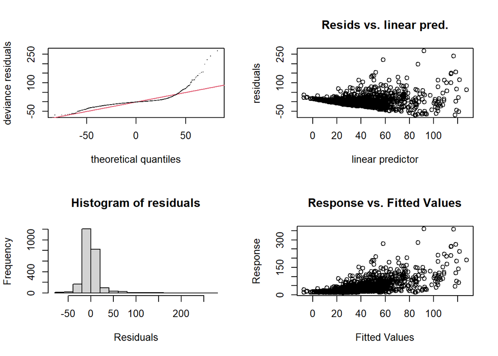

```
##
## Method: REML   Optimizer: outer newton
## full convergence after 6 iterations.
## Gradient range [-0.002579435,0.003244012]
## (score 11234.91 & scale 542.7828).
## Hessian positive definite, eigenvalue range [0.0025796,1209.103].
## Model rank =  303 / 303
##
## Basis dimension (k) checking results. Low p-value (k-index<1) may
## indicate that k is too low, especially if edf is close to k'.
##
##                          k'      edf k-index p-value
## s(subj)             47.0000   0.0117      NA      NA
## s(duration.tt)       9.0000   2.9834       1    0.58
## s(subj,onset_type)  94.0000  55.6321      NA      NA
## s(subj,cluster)    141.0000  95.5560      NA      NA
```

```r
gam.check(m16REML)
```

Doesn’t look very well, skewed right

Fit with loglink

```r
summary(m16REML_log <- bam(dur ~ group.ord*onset_type*cluster + s(duration.tt) + s(subj, bs = "re") + s(subj, onset_type, bs = "re") + s(subj, cluster, bs = "re"), data=df.onset, family =Gamma(link=log)))
```

```
##
## Family: Gamma
## Link function: log
##
## Formula:
## dur ~ group.ord * onset_type * cluster + s(duration.tt) + s(subj,
##     bs = "re") + s(subj, onset_type, bs = "re") + s(subj, cluster,
##     bs = "re")
##
## Parametric coefficients:
##                                              Estimate Std. Error t value
## (Intercept)                                   3.37947    0.08501  39.754
## group.ordtypical                              0.22166    0.11868   1.868
## onset_typecluster                            -0.20391    0.07886  -2.586
## clustersm                                    -0.02030    0.10029  -0.202
## clustersx                                     0.36372    0.10441   3.484
## group.ordtypical:onset_typecluster           -0.29771    0.11002  -2.706
## group.ordtypical:clustersm                   -0.04706    0.14019  -0.336
## group.ordtypical:clustersx                   -0.45399    0.14341  -3.166
## onset_typecluster:clustersm                  -0.11619    0.06173  -1.882
## onset_typecluster:clustersx                  -0.05134    0.06637  -0.774
## group.ordtypical:onset_typecluster:clustersm  0.02169    0.08594   0.252
## group.ordtypical:onset_typecluster:clustersx  0.58055    0.09079   6.394
##                                              Pr(>|t|)
## (Intercept)                                   < 2e-16 ***
## group.ordtypical                             0.061939 .
## onset_typecluster                            0.009775 **
## clustersm                                    0.839592
## clustersx                                    0.000504 ***
## group.ordtypical:onset_typecluster           0.006865 **
## group.ordtypical:clustersm                   0.737144
## group.ordtypical:clustersx                   0.001568 **
## onset_typecluster:clustersm                  0.059926 .
## onset_typecluster:clustersx                  0.439278
## group.ordtypical:onset_typecluster:clustersm 0.800769
## group.ordtypical:onset_typecluster:clustersx 1.96e-10 ***
## ---
## Signif. codes:  0 '***' 0.001 '**' 0.01 '*' 0.05 '.' 0.1 ' ' 1
##
## Approximate significance of smooth terms:
##                          edf Ref.df     F  p-value
## s(duration.tt)     2.962e+00   3.79 48.68  < 2e-16 ***
## s(subj)            7.106e-05  45.00  0.00  0.95002
## s(subj,onset_type) 5.686e+01  90.00 12.59  0.00656 **
## s(subj,cluster)    1.007e+02 133.00 13.18 2.44e-06 ***
## ---
## Signif. codes:  0 '***' 0.001 '**' 0.01 '*' 0.05 '.' 0.1 ' ' 1
##
## R-sq.(adj) =  0.458   Deviance explained =   67%
## fREML = 1688.2  Scale est. = 0.19454   n = 2426
```

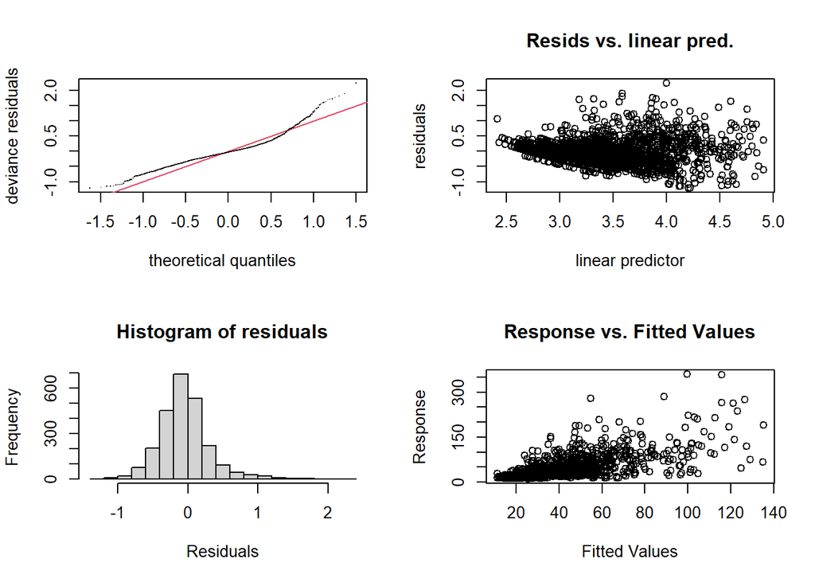

```
##
## Method: fREML   Optimizer: perf newton
## full convergence after 13 iterations.
## Gradient range [-1.146674e-05,2.406441e-05]
## (score 1688.225 & scale 0.1945419).
## Hessian positive definite, eigenvalue range [1.146676e-05,1209.359].
## Model rank =  303 / 303
##
## Basis dimension (k) checking results. Low p-value (k-index<1) may
## indicate that k is too low, especially if edf is close to k'.
##
##                          k'      edf k-index p-value
## s(duration.tt)     9.00e+00 2.96e+00    0.96    0.12
## s(subj)            4.70e+01 7.11e-05      NA      NA
## s(subj,onset_type) 9.40e+01 5.69e+01      NA      NA
## s(subj,cluster)    1.41e+02 1.01e+02      NA      NA
```

```r
gam.check(m16REML_log)
```

Still doesn’t look great.

Model criticism, trimming:

```r
df.onset2 <- df.onset[abs(scale(resid(m16REML_log))) < 2.5, ] # trim model
(1 - (nrow(df.onset2))/nrow(df.onset)) * 100
```

```
## [1] 3.009068
```

3.0% removed

Refit:

```r
summary(m16REML_log_trim <- bam(dur ~ group*onset_type*cluster + s(duration.tt) + s(subj, bs = "re") + s(subj, onset_type, bs = "re") + s(subj, cluster, bs = "re"), data=df.onset2, family =Gamma(link=log)))
```

```
##
## Family: Gamma
## Link function: log
##
## Formula:
## dur ~ group * onset_type * cluster + s(duration.tt) + s(subj,
##     bs = "re") + s(subj, onset_type, bs = "re") + s(subj, cluster,
##     bs = "re")
##
## Parametric coefficients:
##                                           Estimate Std. Error t value Pr(>|t|)
## (Intercept)                               3.311997   0.079463  41.680  < 2e-16
## grouptypical                              0.252073   0.111008   2.271 0.023259
## onset_typecluster                        -0.157354   0.067587  -2.328 0.019995
## clustersm                                -0.027178   0.094897  -0.286 0.774605
## clustersx                                 0.271053   0.098734   2.745 0.006096
## grouptypical:onset_typecluster           -0.341159   0.094376  -3.615 0.000307
## grouptypical:clustersm                   -0.008354   0.132669  -0.063 0.949794
## grouptypical:clustersx                   -0.428908   0.135693  -3.161 0.001595
## onset_typecluster:clustersm              -0.113007   0.044505  -2.539 0.011180
## onset_typecluster:clustersx              -0.009301   0.049007  -0.190 0.849496
## grouptypical:onset_typecluster:clustersm  0.003378   0.062015   0.054 0.956569
## grouptypical:onset_typecluster:clustersx  0.582107   0.066981   8.691  < 2e-16
##
## (Intercept)                              ***
## grouptypical                             *
## onset_typecluster                        *
## clustersm
## clustersx                                **
## grouptypical:onset_typecluster           ***
## grouptypical:clustersm
## grouptypical:clustersx                   **
## onset_typecluster:clustersm              *
## onset_typecluster:clustersx
## grouptypical:onset_typecluster:clustersm
## grouptypical:onset_typecluster:clustersx ***
## ---
## Signif. codes:  0 '***' 0.001 '**' 0.01 '*' 0.05 '.' 0.1 ' ' 1
##
## Approximate significance of smooth terms:
##                          edf  Ref.df      F  p-value
## s(duration.tt)     1.379e+00   1.672 106.83  < 2e-16 ***
## s(subj)            3.695e-05  45.000   0.00   0.8851
## s(subj,onset_type) 5.768e+01  90.000  31.70   0.0164 *
## s(subj,cluster)    1.077e+02 133.000  34.42 4.38e-06 ***
## ---
## Signif. codes:  0 '***' 0.001 '**' 0.01 '*' 0.05 '.' 0.1 ' ' 1
##
## R-sq.(adj) =   0.62   Deviance explained = 74.2%
## fREML = 904.09  Scale est. = 0.099556  n = 2353
```

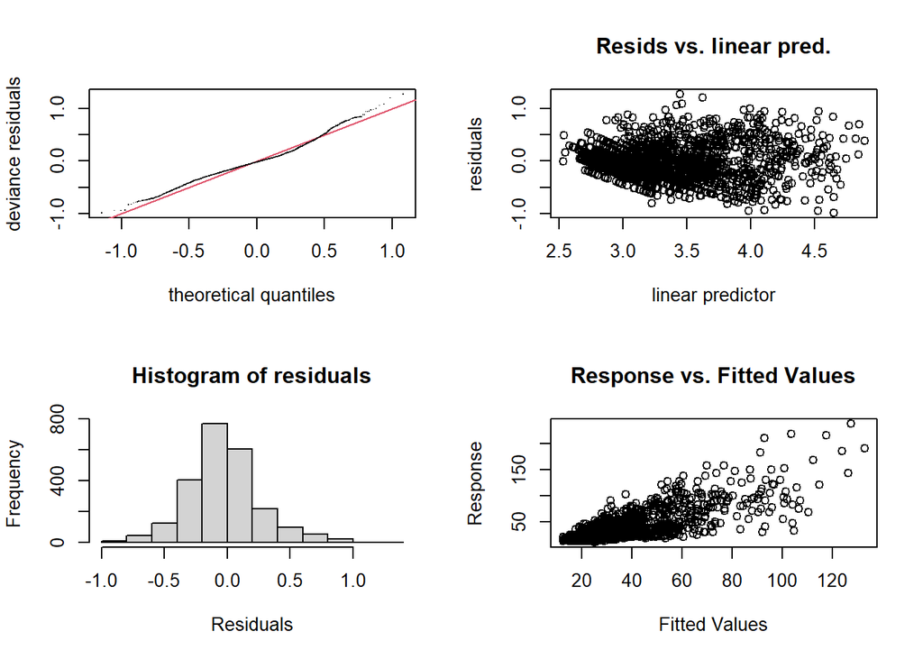

```
##
## Method: fREML   Optimizer: perf newton
## full convergence after 14 iterations.
## Gradient range [-4.56407e-06,1.320756e-06]
## (score 904.0901 & scale 0.09955627).
## Hessian positive definite, eigenvalue range [4.564077e-06,1173.304].
## Model rank =  303 / 303
##
## Basis dimension (k) checking results. Low p-value (k-index<1) may
## indicate that k is too low, especially if edf is close to k'.
##
##                          k'      edf k-index p-value
## s(duration.tt)     9.00e+00 1.38e+00    1.01    0.79
## s(subj)            4.70e+01 3.69e-05      NA      NA
## s(subj,onset_type) 9.40e+01 5.77e+01      NA      NA
## s(subj,cluster)    1.41e+02 1.08e+02      NA      NA
```

```r
gam.check(m16REML_log_trim)
```

Looks fine.

Visualize:

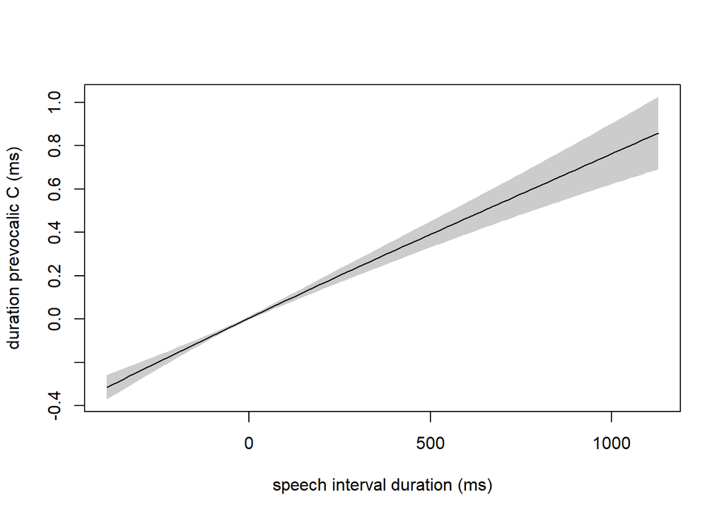

```r
plot(m16REML_log_trim, select = 1, shade = T, rug = F, xlab = "speech interval duration (ms)", ylab = "duration prevocalic C (ms)")
```

```
## Summary:
##  * group : factor; set to the value(s): PD.
##  * onset_type : factor; set to the value(s): cluster, singleton. (Might be canceled as random effect, check below.)
##  * cluster : factor; set to the value(s): sp. (Might be canceled as random effect, check below.)
##  * duration.tt : numeric predictor; set to the value(s): -49.1049051937346.
##  * subj : factor; set to the value(s): CTRL21. (Might be canceled as random effect, check below.)
##  * NOTE : The following random effects columns are canceled: s(subj),s(subj,onset_type),s(subj,cluster)
##
```

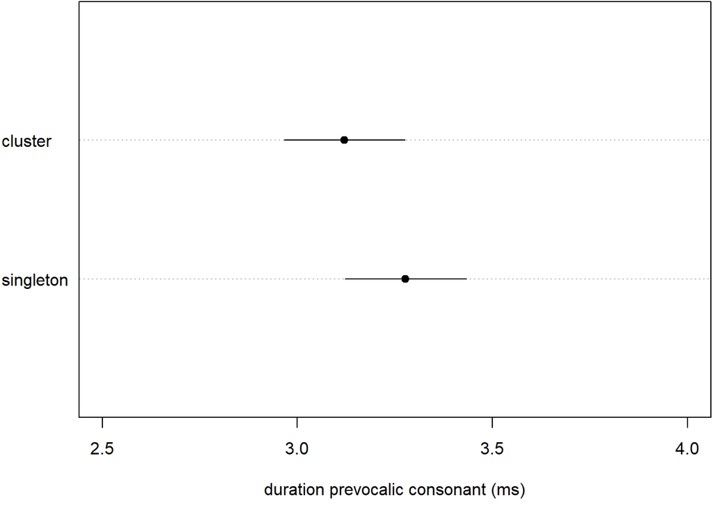

```r
par(mar = c(4.5, 0.1, 0.1, 0.1)) # Set the margin on all sides to 2
plot_parametric(m16REML_log_trim, cond = list(group = "PD", cluster = c("sp")), pred=list(onset_type = c("singleton", "cluster")), main = "", xlim=c(2.5,4), xlab = "duration prevocalic consonant (ms)")
```

```
## Summary:
##  * group : factor; set to the value(s): PD.
##  * onset_type : factor; set to the value(s): cluster, singleton. (Might be canceled as random effect, check below.)
##  * cluster : factor; set to the value(s): sm. (Might be canceled as random effect, check below.)
##  * duration.tt : numeric predictor; set to the value(s): -49.1049051937346.
##  * subj : factor; set to the value(s): CTRL21. (Might be canceled as random effect, check below.)
##  * NOTE : The following random effects columns are canceled: s(subj),s(subj,onset_type),s(subj,cluster)
##
```

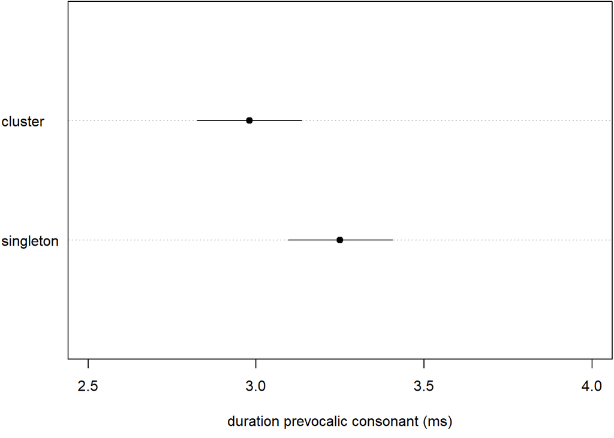

```r
plot_parametric(m16REML_log_trim, cond = list(group = "PD", cluster = c("sm")), pred=list(onset_type = c("singleton", "cluster")), main = "", xlim=c(2.5,4), xlab = "duration prevocalic consonant (ms)")
```

```
## Summary:
##  * group : factor; set to the value(s): PD.
##  * onset_type : factor; set to the value(s): cluster, singleton. (Might be canceled as random effect, check below.)
##  * cluster : factor; set to the value(s): sx. (Might be canceled as random effect, check below.)
##  * duration.tt : numeric predictor; set to the value(s): -49.1049051937346.
##  * subj : factor; set to the value(s): CTRL21. (Might be canceled as random effect, check below.)
##  * NOTE : The following random effects columns are canceled: s(subj),s(subj,onset_type),s(subj,cluster)
##
```

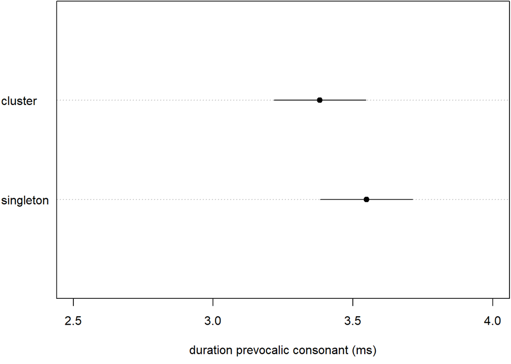

```r
plot_parametric(m16REML_log_trim, cond = list(group = "PD", cluster = c("sx")), pred=list(onset_type = c("singleton", "cluster")), main = "", xlim=c(2.5,4), xlab = "duration prevocalic consonant (ms)")
```

```
## Summary:
##  * group : factor; set to the value(s): typical.
##  * onset_type : factor; set to the value(s): cluster, singleton. (Might be canceled as random effect, check below.)
##  * cluster : factor; set to the value(s): sp. (Might be canceled as random effect, check below.)
##  * duration.tt : numeric predictor; set to the value(s): -49.1049051937346.
##  * subj : factor; set to the value(s): CTRL21. (Might be canceled as random effect, check below.)
##  * NOTE : The following random effects columns are canceled: s(subj),s(subj,onset_type),s(subj,cluster)
##
```

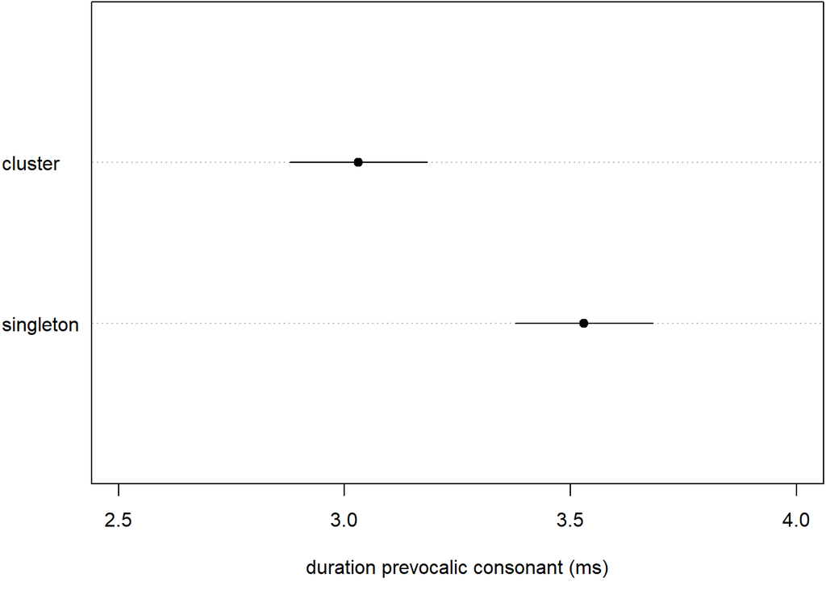

```r
plot_parametric(m16REML_log_trim, cond = list(group = "typical", cluster = c("sp")), pred=list(onset_type = c("singleton", "cluster")), main = "", xlim=c(2.5,4), xlab = "duration prevocalic consonant (ms)")
```

```
## Summary:
##  * group : factor; set to the value(s): typical.
##  * onset_type : factor; set to the value(s): cluster, singleton. (Might be canceled as random effect, check below.)
##  * cluster : factor; set to the value(s): sm. (Might be canceled as random effect, check below.)
##  * duration.tt : numeric predictor; set to the value(s): -49.1049051937346.
##  * subj : factor; set to the value(s): CTRL21. (Might be canceled as random effect, check below.)
##  * NOTE : The following random effects columns are canceled: s(subj),s(subj,onset_type),s(subj,cluster)
##
```

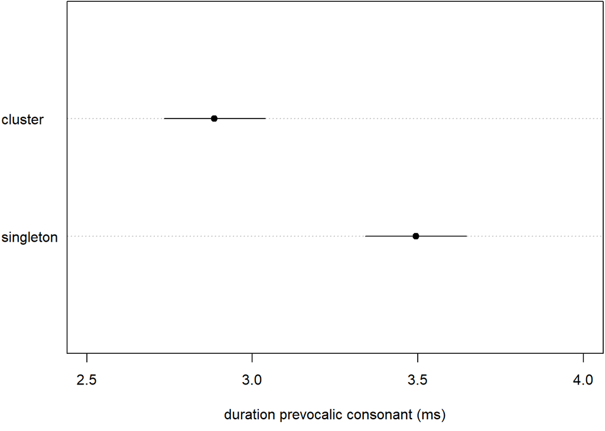

```r
plot_parametric(m16REML_log_trim, cond = list(group = "typical", cluster = c("sm")), pred=list(onset_type = c("singleton", "cluster")), main = "", xlim=c(2.5,4), xlab = "duration prevocalic consonant (ms)", ylim=c(1,-1))
```

```
## Summary:
##  * group : factor; set to the value(s): typical.
##  * onset_type : factor; set to the value(s): cluster, singleton. (Might be canceled as random effect, check below.)
##  * cluster : factor; set to the value(s): sx. (Might be canceled as random effect, check below.)
##  * duration.tt : numeric predictor; set to the value(s): -49.1049051937346.
##  * subj : factor; set to the value(s): CTRL21. (Might be canceled as random effect, check below.)
##  * NOTE : The following random effects columns are canceled: s(subj),s(subj,onset_type),s(subj,cluster)
##
```

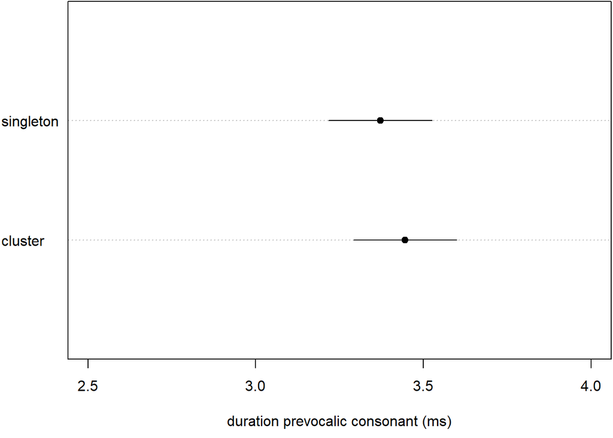

```r
plot_parametric(m16REML_log_trim, cond = list(group = "typical", cluster = c("sx")), pred=list(onset_type = c("singleton", "cluster")), main = "", xlim=c(2.5,4), xlab = "duration prevocalic consonant (ms)", ylim=c(1,-1))
```

Latex table function:

```r
gamtabs2 <- function (model, caption = " ", label = "tab.gam",
    pnames = NA, snames = NA, ptab = NA, stab = NA, ...)
{
    if (!requireNamespace("xtable", quietly = TRUE)) {
        stop("Package 'xtable' needed for this function to work. Please install it.",
            call. = FALSE)
    }
    sum.gam <- model
    if (!inherits(model, "summary.gam")) {
        sum.gam <- summary(model)
    }
    if (is.na(ptab[1])) {
        ptab = as.data.frame(sum.gam$p.table, stringsAsFactors = FALSE)
    }
    if (is.na(stab[1])) {
        stab = as.data.frame(sum.gam$s.table, stringsAsFactors = FALSE)
    }
    if (!is.na(pnames[1])) {
        rownames(ptab) = pnames
    }
    if (!is.na(snames[1])) {
        rownames(stab) = snames
    }
    colnames(ptab)[4] = "p-value"
    colnames(ptab)[3] = "t-value"
    ptab.cnames = colnames(ptab)
    stab.cnames = colnames(stab)
    stab.cnames[3] = "F-value"
    colnames(ptab) = c("A", "B", "C", "D")
    if (ncol(stab) != 0) {
        colnames(stab) = colnames(ptab)
    }
    tab = rbind(ptab, stab)
    colnames(tab) = ptab.cnames
    tab = round(tab, 4)
    m = data.frame(matrix(0, nrow(tab), ncol(tab)), stringsAsFactors = FALSE)
    for (i in 1:nrow(tab)) {
        for (j in 1:4) {
            if ((j == 4) & (tab[i, j] < 1e-03)) {
                m[i, j] = "< 0.001"
            }
            else {
                m[i, j] = sprintf("%3.3f", tab[i, j])
            }
        }
    }
    colnames(m) = colnames(tab)
    rownames(m) = rownames(tab)
    tab = m
    tab2 = rbind(c(ptab.cnames), tab[1:nrow(ptab), ])
    if (nrow(stab) > 0) {
        tab2 = rbind(tab2, c(stab.cnames), tab[(nrow(ptab) +
            1):nrow(tab), ])
    }
    if (nrow(stab)) {
        rownames(tab2)[(nrow(ptab) + 2)] = "B. smooth terms"
    }
    rownames(tab2)[1] = "A. parametric coefficients"
    for (i in 1:nrow(tab2)) {
        if (tab2[i, 4] == "0")
            tab2[i, 4] = "< 0.0001"
        if (length(grep("\\.", tab2[i, 2])) == 0)
            tab2[i, 2] = paste(tab2[i, 2], ".0000", sep = "")
    }
    print(xtable::xtable(tab2, caption = caption, label = label,
        align = "lrrrr"), include.colnames = FALSE, hline.after = c(0,
        (nrow(ptab) + 1), nrow(tab2)), ...)
}
```

Latex table:

```r
options(xtable.comment = FALSE)
gamtabs2(m16REML_log_trim)
```

```
## \begin{table}[ht]
## \centering
## \begin{tabular}{lrrrr}
##    \hline
## A. parametric coefficients & Estimate & Std. Error & t-value & p-value \\
##   (Intercept) & 3.312 & 0.080 & 41.680 & $<$ 0.001 \\
##   grouptypical & 0.252 & 0.111 & 2.271 & 0.023 \\
##   onset\_typecluster & -0.157 & 0.068 & -2.328 & 0.020 \\
##   clustersm & -0.027 & 0.095 & -0.286 & 0.775 \\
##   clustersx & 0.271 & 0.099 & 2.745 & 0.006 \\
##   grouptypical:onset\_typecluster & -0.341 & 0.094 & -3.615 & $<$ 0.001 \\
##   grouptypical:clustersm & -0.008 & 0.133 & -0.063 & 0.950 \\
##   grouptypical:clustersx & -0.429 & 0.136 & -3.161 & 0.002 \\
##   onset\_typecluster:clustersm & -0.113 & 0.044 & -2.539 & 0.011 \\
##   onset\_typecluster:clustersx & -0.009 & 0.049 & -0.190 & 0.850 \\
##   grouptypical:onset\_typecluster:clustersm & 0.003 & 0.062 & 0.054 & 0.957 \\
##   grouptypical:onset\_typecluster:clustersx & 0.582 & 0.067 & 8.691 & $<$ 0.001 \\
##    \hline
## B. smooth terms & edf & Ref.df & F-value & p-value \\
##   s(duration.tt) & 1.379 & 1.672 & 106.826 & $<$ 0.001 \\
##   s(subj) & 0.000 & 45.000 & 0.000 & 0.885 \\
##   s(subj,onset\_type) & 57.678 & 90.000 & 31.699 & 0.016 \\
##   s(subj,cluster) & 107.682 & 133.000 & 34.418 & $<$ 0.001 \\
##    \hline
## \end{tabular}
## \caption{ }
## \label{tab.gam}
## \end{table}
```